# US Car Accidents

Revealjs Presentation

Group 3: Anthony Fitch, Adib Mazloom, Annabelle Petherbridge, Julia Bautista, & William Jackson

GBA 5910, Cal Poly Pomona

2025-05-01

# Research Objective #4

This study aims to analyze the temporal distribution of car accidents, focusing on the frequency of incidents by day of the week and time of day.

**Dependent Variable:**

- **Accident Frequency**: The number of accidents occurring within specific time intervals (e.g., hourly or daily).

**Independent Variables:**

- **Time of Day**: Categorized into periods such as morning (6–9 AM), afternoon (12–3 PM), evening (4–7 PM), and night (8 PM–5 AM).
- **Day of Week**: Days categorized from Monday to Sunday.

**Operationalization of Scale:**

| **Variable** | **Operationalization** | **Scale Type** |
| --- | --- | --- |
| **Day** | Day of the week (e.g., Monday, Tuesday, etc.) | Ordinal |
| **Hour** | Hour of the day (24-hour format) | Ratio |

# Accidents by Day of Week

```r
accidents_by_day <- data %>%
  count(Day_of_week) %>%
  arrange(n) %>%
  mutate(Day_of_week = factor(Day_of_week, levels = c("Monday", "Tuesday", "Wednesday", "Thursday", "Friday", "Saturday", "Sunday")))

ggplot(accidents_by_day, aes(x = Day_of_week, y = n, fill = Day_of_week)) +
  geom_bar(stat = "identity") +
  geom_text(aes(label = n), vjust = -0.3) +
  labs(x = "Day of the Week", y = "Number of Accidents", title = "Accidents by Day of the Week") +
  theme_minimal() +
  theme(axis.text.x = element_text(angle = 45, hjust = 1))
```

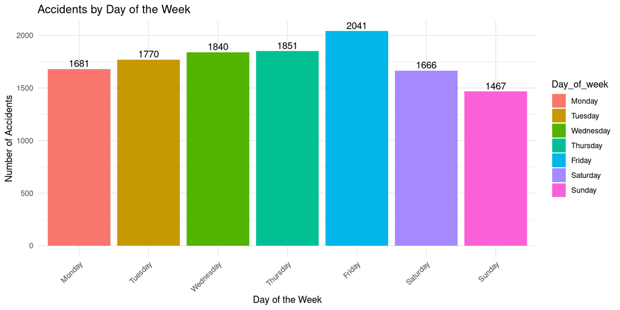

**Analysis:**

- Counted the number of accidents for each day of the week
- Visualized the distribution using a bar chart

**Findings:**

- Accident count is highest on weekdays.
- The greatest number of accidents occur on Fridays.
- The fewest number of accidents occur on Saturday and Sunday.

# Accidents by Hour

```r
# Count accidents by hour
accidents_by_hour <- data %>%
  count(Hour) %>%
  arrange(Hour)

# Plot
ggplot(accidents_by_hour, aes(x = Hour, y = n)) +
  geom_line(group = 1, color = "darkred") +
  geom_point(color = "darkred") +
  geom_text(aes(label = n), vjust = -0.3, size = 3.5) +
  labs(x = "Hour of the Day", y = "Number of Accidents", title = "Accidents by Time of Day") +
  theme_minimal()
```

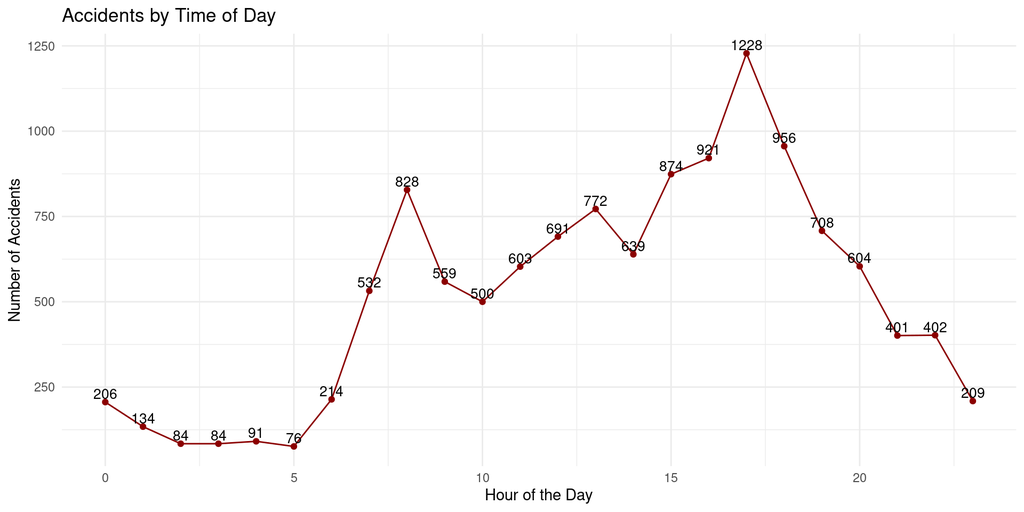

**Analysis:**

- Counted the number of accidents for each hour of the day
- Visualized the distribution using a line chart

**Findings:**

- Accident frequency is highest at 8am and 5pm.
- **Morning Rush (8:00 AM)**: This peak coincides with the morning commute, where individuals are traveling to work or school. The roads are more congested, leading to increased chances of accidents
- **Evening Rush (5:00 PM):** The evening peak aligns with the end of the workday, leading to another surge in traffic as people head home.

# Accident Frequency: Weekday vs Weekend

```r
# Create 'Weekend' variable
data <- data %>%
  mutate(Weekend = ifelse(Day_of_week %in% c("Saturday", "Sunday"), "Weekend", "Weekday"))

# Count accidents by 'Weekend' and 'Hour'
accidents_by_type_time <- data %>%
  count(Weekend, Hour) %>%
  arrange(Weekend, Hour)

# Calculate overall accidents by 'Hour'
accidents_overall <- data %>%
  count(Hour) %>%
  mutate(Weekend = "Overall") %>%
  arrange(Hour)

# Combine
combined_data <- bind_rows(accidents_by_type_time, accidents_overall)

# Plot
ggplot(combined_data, aes(x = Hour, y = n, color = Weekend)) +
  geom_line() +
  labs(x = "Hour of the Day", y = "Number of Accidents", title = "Accidents by Time of Day: Weekday, Weekend, and Overall") +
  scale_color_manual(values = c("Weekday" = "blue", "Weekend" = "red", "Overall" = "black")) +
  theme_minimal()
```

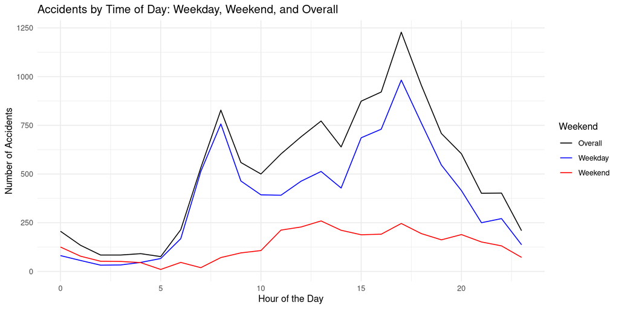

**Analysis:**

- Categorized days into Weekday (Monday–Friday) and Weekend (Saturday–Sunday)
- Counted accidents by `Weekend` and `Hour`
- Visualized the distribution using a line chart

# Accident Frequency Findings: Weekday vs Weekend

**Findings:**

- Majority of accidents occur on weekdays. Likely driven by number of drivers on the road heading to and from work.
- Distribution of accident frequency by hour shows significant variance between weekdays and weekend
- In order to ensure adequate emergency services, we should have more first responders on duty during weekdays from 6-10am and 3-7pm.
- Weekends should be staffed differently to account for lower number of accidents and different frequency by hour.

# Accident Frequency: Weekend

```r
# Filter data for weekends only
weekend_data <- data %>%
  filter(Day_of_week %in% c("Saturday", "Sunday"))

# Count accidents by Hour
accidents_by_hour <- weekend_data %>%
  count(Hour) %>%
  arrange(Hour)

# Plot
ggplot(accidents_by_hour, aes(x = Hour, y = n)) +
  geom_bar(stat = "identity", fill = "steelblue", width = 0.8) +
  labs(x = "Hour of the Day", y = "Number of Accidents", title = "Accidents by Hour: Weekend Only") +
  theme_minimal() +
  theme(axis.text.x = element_text(angle = 45, hjust = 1))
```

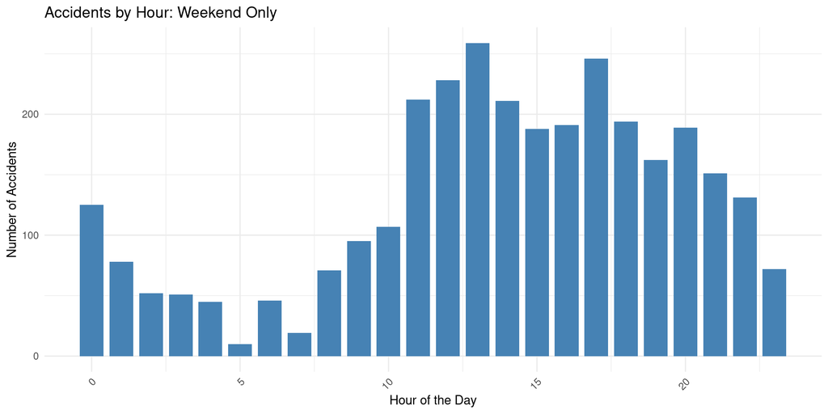

**Analysis:**

**Findings:**

- Accident frequency peaks at 1pm and 5pm.
- **Afternoon (1:00 PM)**: This time sees an increase in accidents as people engage in recreational activities, errands, or social gatherings.

  **Evening (5:00 PM)**: Similar to weekdays, the evening peak occurs as people return home from various activities.

# Summary of Research and Findings: Day of the Week Analysis

- Weekdays (Monday–Friday):

```
-   Accident Frequency: Higher accident counts are observed on weekdays.

-   Peak Days: Fridays report the highest number of accidents.
```

- Weekends (Saturday–Sunday):

```
-   Accident Frequency: Lower accident counts compared to weekdays.

-   Peak Days: Saturdays and Sundays have fewer accidents overall.
```

# Summary of Research and Findings: Time of Day Analysis

- Weekdays:

```
-   Morning Peak (8:00 AM): Increased accidents due to morning commutes.

    Evening Peak (5:00 PM): Higher accident frequency as individuals return home from work.
```

- Weekends:

```
-   Afternoon Peak (1:00 PM): Rise in accidents as people engage in recreational activities.

-   Evening Peak (5:00 PM): Similar to weekdays, accidents increase as individuals return from daytime activities.
```

# Summary of Research and Findings: Final Insights and Observations

- Weekday Accidents: The higher frequency of accidents on weekdays, particularly on Fridays, may be attributed to increased traffic volume during work commutes.
- Weekend Accidents: The afternoon peak on weekends suggests that recreational and social activities contribute to higher accident frequencies during these times.
- Evening Patterns: The consistent evening peak across both weekdays and weekends indicates that returning home from various activities is a common factor influencing accident frequency.